# R Notebook

```r
library(rpart)
library(rpart.plot)
library(tidyverse)
library(GGally)
library(tidyverse)
titanic_set <- read_csv('data/titanic_decision_tree_data.csv')
shuffle_index <- sample(1:nrow(titanic_set))

# shuffle the data so class order isn't in order - need this for training/testing split later on
titanic_set <- titanic_set[shuffle_index, ]
```

```r
titanic_clean <- titanic_set %>%
  drop_na(survived) %>%
  select(c(pclass, sex, age, sib_sp, parch, fare, embarked, survived)) %>%
  mutate(pclass = factor(pclass, levels = c(3,2,1), labels = c("low", "middle", "high")),
         age_status = as.factor(if_else(age < 17, "child", "adult")),
         embarked = as.factor(embarked),
         survived = factor(survived, levels = c(0,1), labels = c("Dead as a Dodo", "Live and kicking")),
         sex = as.factor(sex)) %>%
  drop_na()
```

```r
titanic_clean
```

| pclass | sex | age | sib_sp | parch | fare | embarked | survived | age_status |
| --- | --- | --- | --- | --- | --- | --- | --- | --- |
| middle | male | 34.00 | 1 | 0 | 21.0000 | S | Dead as a Dodo | adult |
| low | male | 20.00 | 1 | 1 | 15.7417 | C | Live and kicking | adult |
| middle | female | 28.00 | 0 | 0 | 13.0000 | S | Live and kicking | adult |
| middle | male | 60.00 | 1 | 1 | 39.0000 | S | Dead as a Dodo | adult |
| low | male | 23.00 | 0 | 0 | 7.8958 | S | Dead as a Dodo | adult |
| high | male | 60.00 | 0 | 0 | 26.5500 | S | Dead as a Dodo | adult |
| low | male | 33.00 | 0 | 0 | 7.8958 | S | Dead as a Dodo | adult |
| low | male | 2.00 | 3 | 1 | 21.0750 | S | Dead as a Dodo | child |
| low | female | 22.00 | 0 | 0 | 9.8375 | S | Dead as a Dodo | adult |
| low | male | 17.00 | 0 | 0 | 8.6625 | S | Dead as a Dodo | adult |

[output cut: 702 more lines]

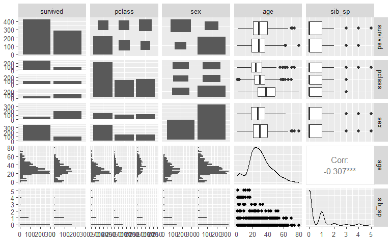

```r
titanic_clean %>%
  select(survived, pclass:sib_sp) %>%
  ggpairs()
```

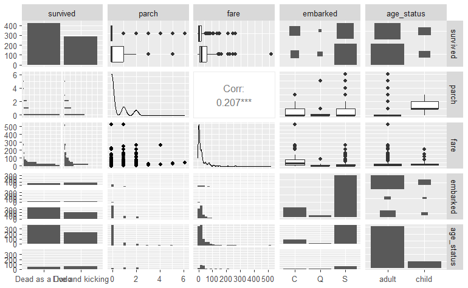

```r
titanic_clean %>%
  select(survived, parch:age_status) %>%
  ggpairs()
```

*Passenger class and sex vary to a large degree* *Age and sibsp appear to have similar median values and ranges for the boxplot* *Parch may be of interest* *Fare, embarked and age_status also show something*

Overall 288 survived and 424 died. 1:1.5.

```r
titanic_clean %>%
  count(survived)
```

| survived | n |
| --- | --- |
| Dead as a Dodo | 424 |
| Live and kicking | 288 |

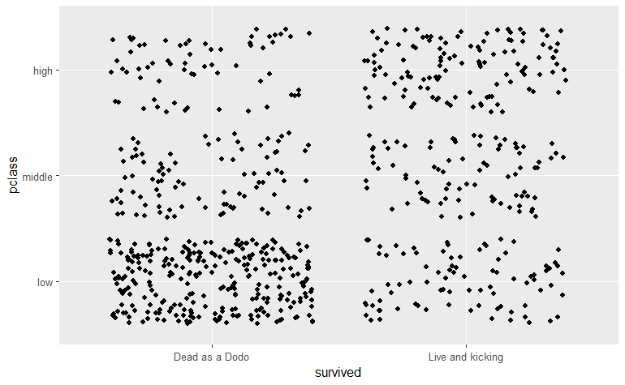

```r
titanic_clean %>%
  ggplot(aes(x = survived, y = pclass))+
  geom_jitter()
```

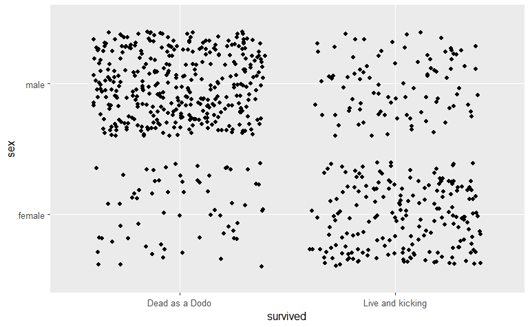

```r
titanic_clean %>%
  ggplot(aes(x = survived, y = sex))+
  geom_jitter()
```

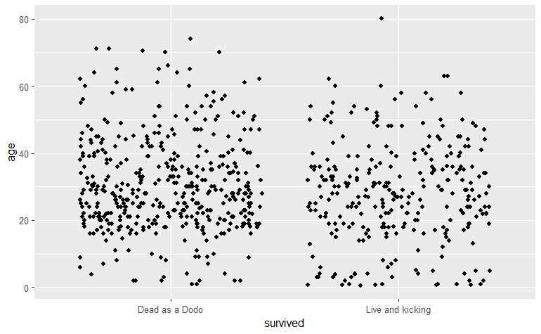

```r
titanic_clean %>%
  ggplot(aes(x = survived, y = age))+
  geom_jitter()
```

More of the lower class died than survived whereas more of the upper class survived than died.

```r
titanic_clean %>%
  group_by(pclass) %>%
  count(survived) %>%
  summarise(survived, survival_rate = n/nrow(titanic_clean))
```

| pclass | survived | survival_rate |
| --- | --- | --- |
| low | Dead as a Dodo | 0.37921348 |
| low | Live and kicking | 0.11938202 |
| middle | Dead as a Dodo | 0.12640449 |
| middle | Live and kicking | 0.11657303 |
| high | Dead as a Dodo | 0.08988764 |
| high | Live and kicking | 0.16853933 |

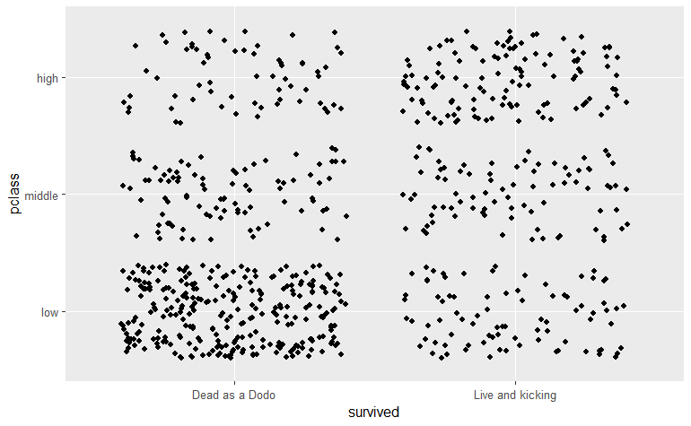

```r
titanic_clean %>%
  ggplot(aes(x = survived, y = pclass))+
  geom_jitter()
```

More females survived at a higher rate than males.

```r
titanic_clean %>%
  group_by(sex) %>%
  count(survived) %>%
  summarise(survived, survival_rate = n/nrow(titanic_clean))
```

| sex | survived | survival_rate |
| --- | --- | --- |
| female | Dead as a Dodo | 0.08988764 |
| female | Live and kicking | 0.27387640 |
| male | Dead as a Dodo | 0.50561798 |
| male | Live and kicking | 0.13061798 |

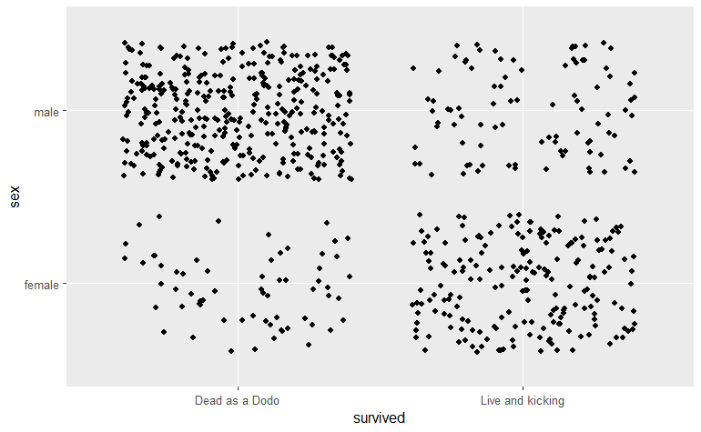

```r
titanic_clean %>%
  ggplot(aes(x = survived, y = sex))+
  geom_jitter()
```

There is some difference based on where people embarked but the majority were in Southampton.

```r
titanic_clean %>%
  group_by(embarked) %>%
  count(survived) %>%
  summarise(survived, survival_rate = n/nrow(titanic_clean))
```

| embarked | survived | survival_rate |
| --- | --- | --- |
| C | Dead as a Dodo | 0.07162921 |
| C | Live and kicking | 0.11095506 |
| Q | Dead as a Dodo | 0.02808989 |
| Q | Live and kicking | 0.01123596 |
| S | Dead as a Dodo | 0.49578652 |
| S | Live and kicking | 0.28230337 |

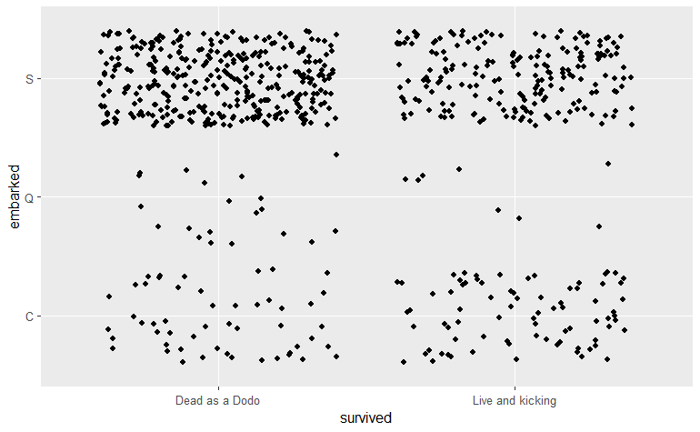

```r
titanic_clean %>%
  ggplot(aes(x = survived, y = embarked))+
  geom_jitter()
```

Children seem to survive at a similar rate to die but adults are much lower.

```r
titanic_clean %>%
  group_by(age_status) %>%
  count(survived) %>%
  summarise(survived, survival_rate = n/nrow(titanic_clean))
```

| age_status | survived | survival_rate |
| --- | --- | --- |
| adult | Dead as a Dodo | 0.53230337 |
| adult | Live and kicking | 0.32724719 |
| child | Dead as a Dodo | 0.06320225 |
| child | Live and kicking | 0.07724719 |

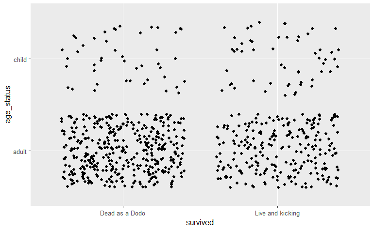

```r
titanic_clean %>%
  ggplot(aes(x = survived, y = age_status))+
  geom_jitter()
```

Maybe some of in sib_sp, quite similar but just more dead than alive

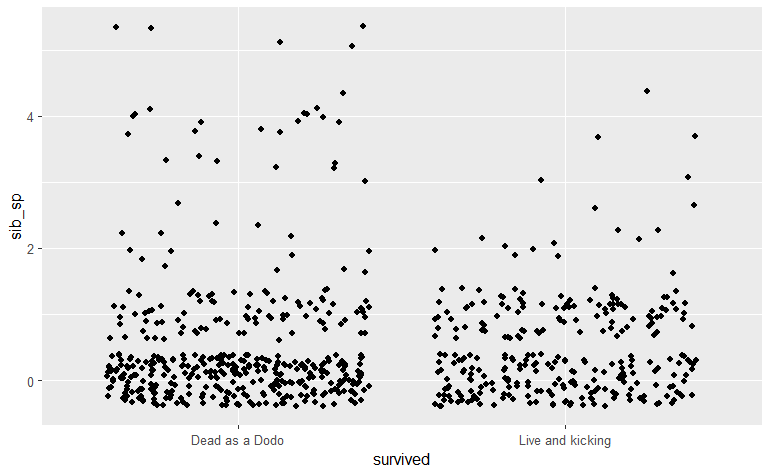

```r
titanic_clean %>%
  ggplot(aes(x = survived, y = sib_sp))+
  geom_jitter()
```

More dead for this split but maybe a similar pattern

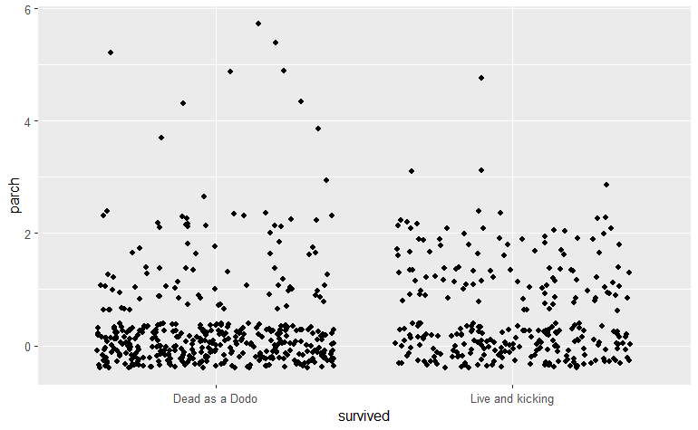

```r
titanic_clean %>%
  ggplot(aes(x = survived, y = parch))+
  geom_jitter()
```

Seems like for survivors may have paid more for tickets.

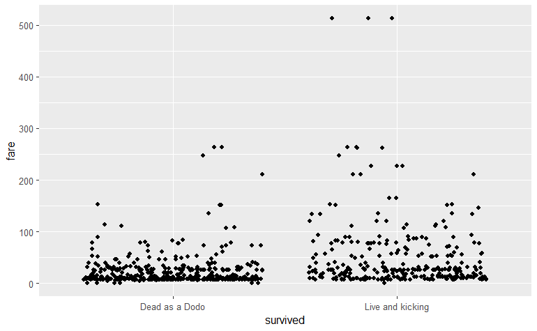

```r
titanic_clean %>%
  ggplot(aes(x = survived, y = fare))+
  geom_jitter()
```

maybe more survived at lower ages?

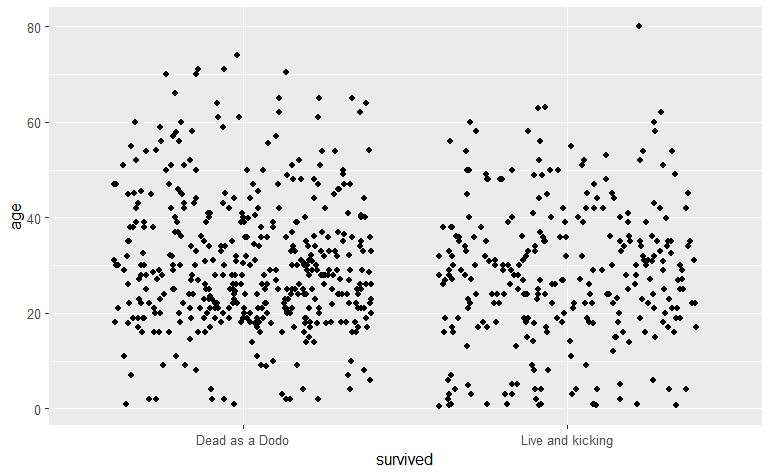

```r
titanic_clean %>%
  ggplot(aes(x = survived, y = age))+
  geom_jitter()
```

*Would think that p-class, sex, fare may be good things to work from, fare may be an alias for p-class*